# Bayesian Methods for Ecological and Environmental Modelling

Spatial Data: Practical 2

Lindsay Banin

September 2019

```r
library(ggplot2)
library(raster)
library(geoR)
```

This practical is performed in geoR - you may want to access the geoR documentation as you go through it - https://cran.r-project.org/web/packages/geoR/geoR.pdf

# Introduction to Case Study 2: Swiss Rainfall

This example makes use of Swiss rainfall data from 1986 available within the geoR package. The full dataset (sic.all) has 467 spatial records (corresponding to weather stations) and is partitioned into (sic.100) which can be used for estimation and (sic.367) which can be used for prediction and validation.There is also a mitrix named sic.borders which defines the Swiss country border.

First, explore the data. We can see that it is already stored as a geodata object and includes location coordinates (coords), rainfall measurements (data), and elevation values (altitude). We can also visualise the data:

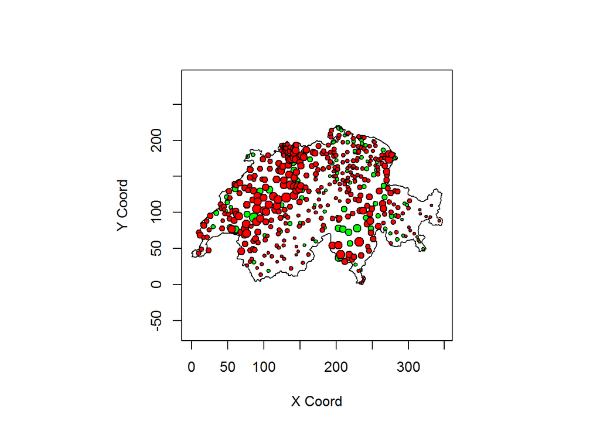

```r
points(sic.100, borders=sic.borders,col="green")
points(sic.367, borders=sic.borders,col="red",add=TRUE)
```

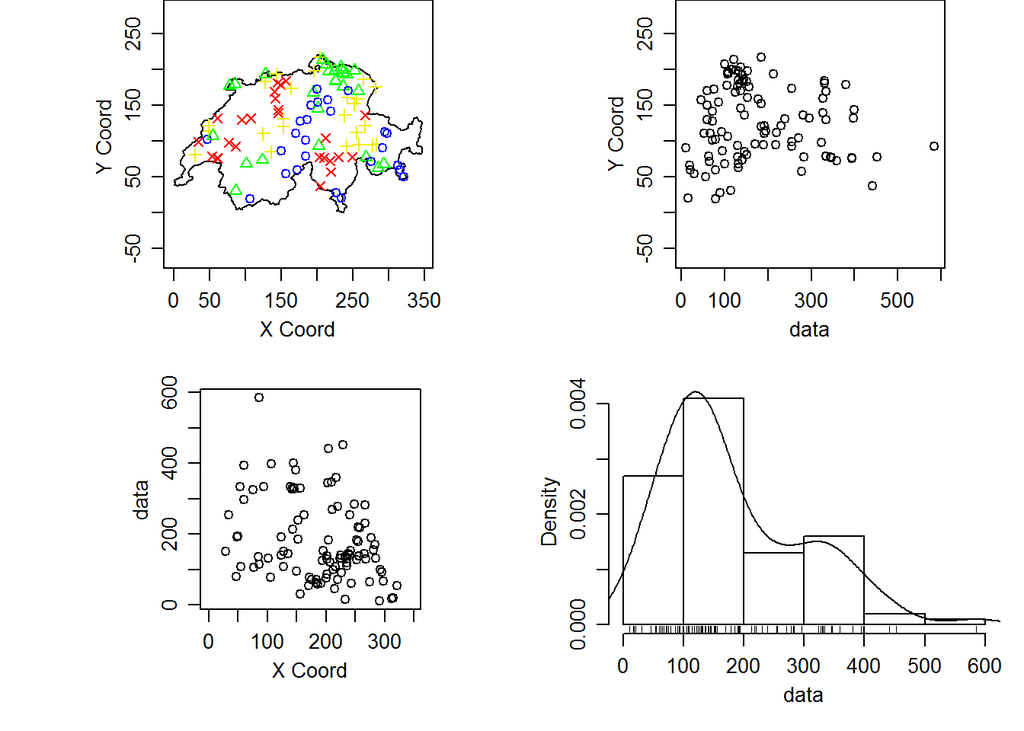

```r
plot.geodata(sic.100,bor=sic.borders)
```

The method we propose assumes that the data are normally distributed. However, the histogram indicates the data are skewed. A square-root transformation improves the approximation to Normal, as shown in the histogram.

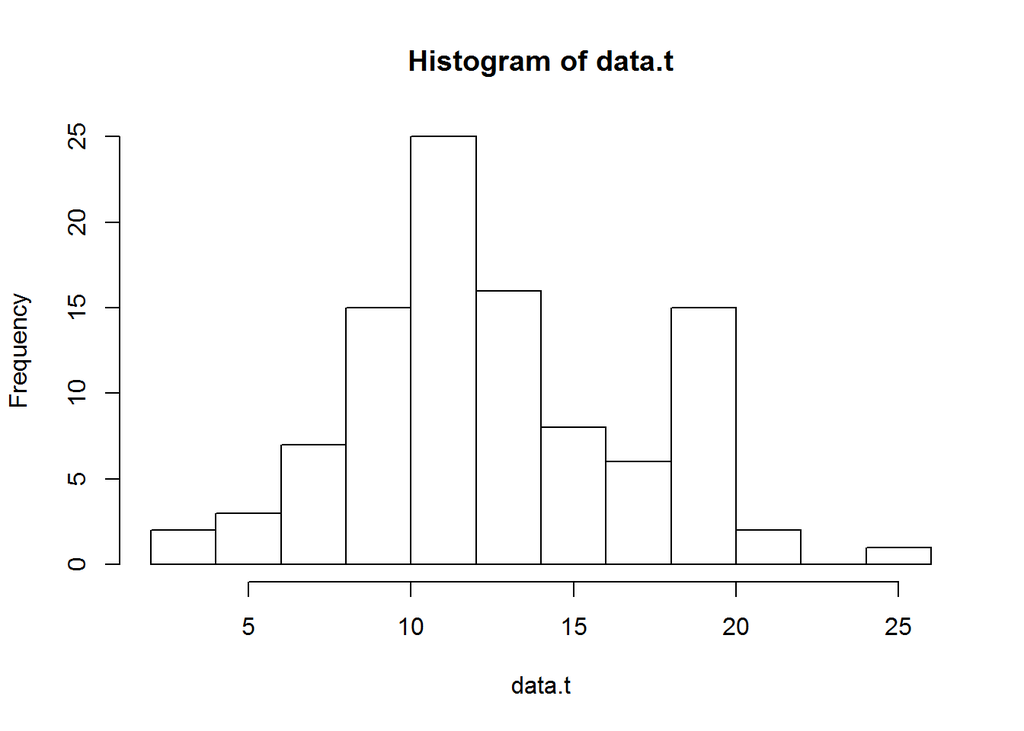

```r
data.t <- (sqrt(sic.100$data))
hist(data.t)
```

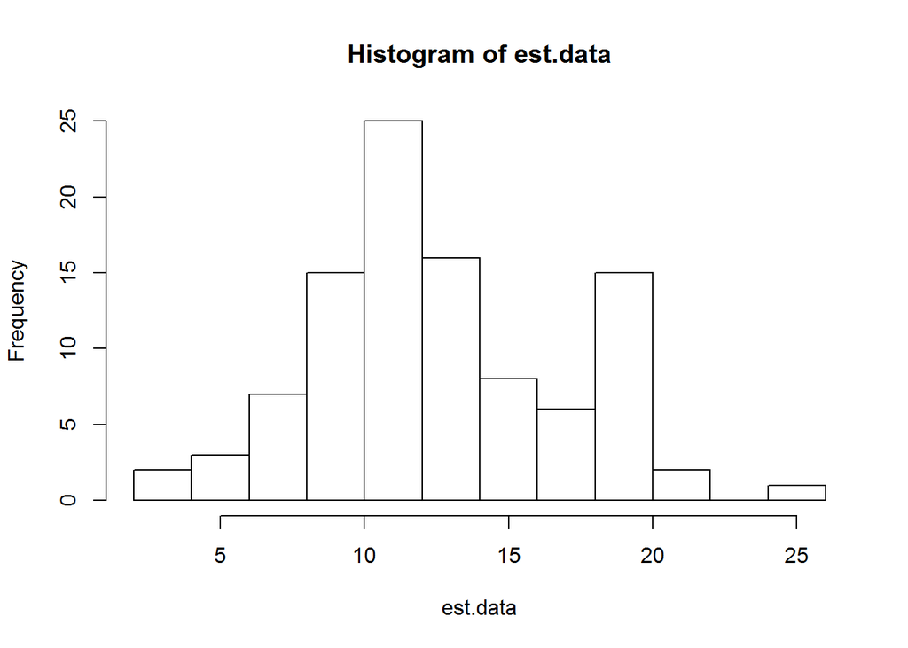

```r
# Looks better!


# Find in sic.all the 100 locations given in sic.100 to be used for estimation
index.est <- which(as.numeric(rownames(sic.all$coords)) %in% as.numeric(rownames(sic.100$coords)))
est.coord <- sic.all$coords[index.est,]
# Square-root transform the rainfall data to approximate a Normal distribution
est.data <- sqrt(sic.all$data[index.est])
est.elevation <- sic.all$altitude[index.est]
hist(est.data)
```

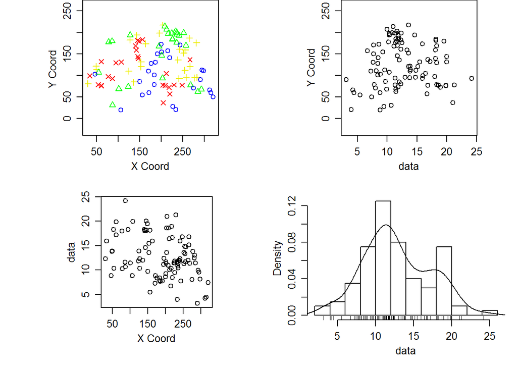

```r
# Prepare data for validation
val.coord <- sic.all$coords[-index.est,]
val.data <- sqrt(sic.all$data[-index.est])
val.elevation <- sic.all$altitude[-index.est]

# Create geodata objects for analysis in geoR
est.df <- data.frame(est.coord,est.data,est.elevation)
est.geo <- as.geodata(est.df, coords.col=1:2, data.col=3, covar.col=4)
plot.geodata(est.geo)
```

```r
val.df <- data.frame(val.coord,val.data,val.elevation)
val.geo <- as.geodata(val.df, coords.col=1:2, data.col=3, covar.col=4)

# Prepare grid for prediction
```

# Construct the variogram

We construct a variogram using the `geoR` `variog()` function. First we see the unbinned variogram cloud (all location pairs at all distances). The second variogram creates bins for separation distance and calculates the mean semivariance in each.

```r
par(mfrow=c(1,2), mar=c(3,3,1,1), mgp =c (2,1,0))
vario.c <- variog(est.geo, op="cloud")
```

```
## variog: computing omnidirectional variogram
```

```r
plot(vario.c)

vario.ex <- variog(est.geo, bin.cloud=TRUE)
```

```
## variog: computing omnidirectional variogram
```

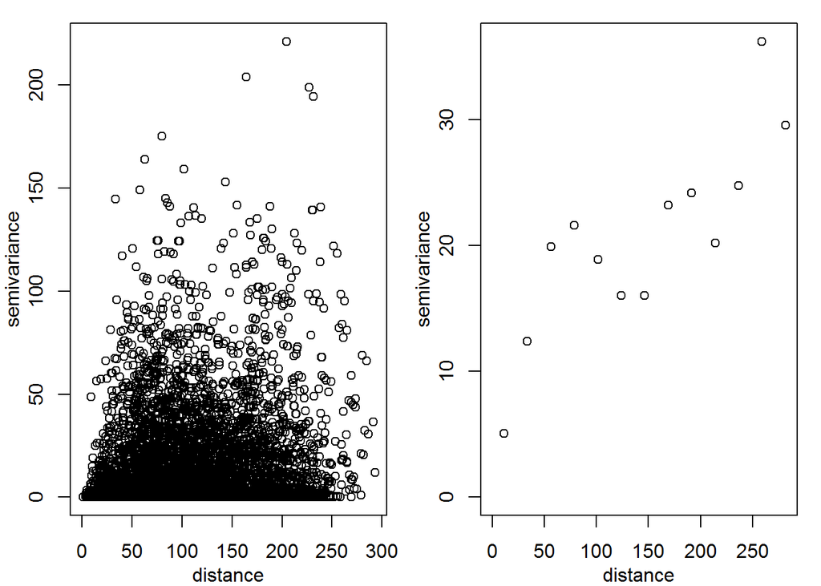

```r
plot(vario.ex)
```

```r
# OLS variogram fits (minimises sum of squares between experimental and theoretical variogram
# ini.cov.pars gives initial values.
vario.sphe<-(variofit(vario.ex,cov.model= "spher",ini.cov.pars=c(18,90)))
```

```
## variofit: covariance model used is spherical
## variofit: weights used: npairs
## variofit: minimisation function used: optim
```

```r
vario.exp<-(variofit(vario.ex,cov.model= "exp",ini.cov.pars=c(18,90)))
```

```
## variofit: covariance model used is exponential
## variofit: weights used: npairs
## variofit: minimisation function used: optim
```

```r
vario.exp2<-(variofit(vario.ex,cov.model= "exp",ini.cov.pars=c(18,90),nug=3))
```

```
## variofit: covariance model used is exponential
## variofit: weights used: npairs
## variofit: minimisation function used: optim
```

```r
vario.mat<-(variofit(vario.ex,cov.model= "matern",ini.cov.pars=c(18,90),nug=0,kappa=0.5))
```

```
## variofit: covariance model used is matern
## variofit: weights used: npairs
## variofit: minimisation function used: optim
```

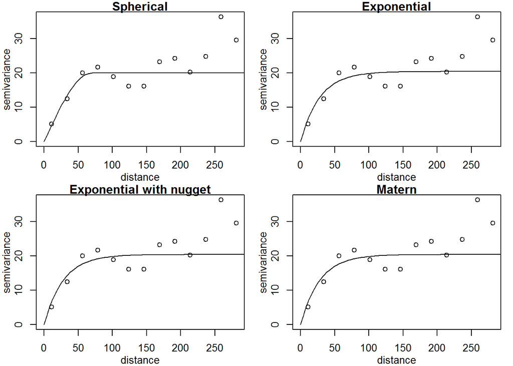

```r
# Notice here the addition of the kappa parameter - a smoothing parameter for the matern correlation function

par(mfrow=c(2,2), mar=c(3,3,1,1), mgp =c (2,1,0))
plot(vario.ex, main="Spherical")
lines(vario.sphe)
plot(vario.ex, main="Exponential")
lines(vario.exp)
plot(vario.ex, main="Exponential with nugget")
lines(vario.exp2)
plot(vario.ex, main="Matern")
lines(vario.mat)
```

# Model estimation

Recall that function ‘krige.bayes’ requires the following components: ‘model.control’, ‘prior.control’ and ‘output.control’. Model.control is where we specify our mean trends (where the default is “cte” or constant over space, 1st or 2nd order polynomial on the coordinates, or as a function of covariates). Here, we also specify our correlation function (cov.model).

In prior.control we specify the priors for $\beta$ (MEAN), $\phi$ (RANGE), $\tau^2$ (NUGGET) and $\sigma^2$ (PARTIAL SILL) parameters. In geoR’s ‘krige.bayes’ function we have a set of possible priors for each parameter (as such, it is not as flexible as some other software).

- range $\phi$ - we assume a uniform distribution between 0 and twice the maximum in the data
- intercept $\tau^2$ - this is specified as a fraction of the asymptote $\sigma^2$, “tausq.rel”. We assume a uniform distribution between 0 and 1.
- asymtote $\sigma^2$ - we assume a “reciprocal” prior, where larger values become diminishingly probable, in inverse proportion to $\sigma^2$
- mean $\beta$ - we assume a uniform distribution between 0 and infinity i.e. completely uninformative; “flat” in the geoR syntax

```r
MC <- model.control(trend.d="cte", trend.l="cte", cov.model="sphe")

maxdist  <- vario.ex$max.dist

PC <- prior.control(beta.prior="flat", sigmasq.prior="reciprocal", phi.prior="uniform",   phi.discrete=seq(0, 2*maxdist, l = 51), tausq.rel.prior="uniform", tausq.rel.discrete = seq(0, 1, by=0.05))

OC <- output.control(n.posterior=10, n.pred = 10, quantile = c(0.1, 0.25, 0.5, 0.75, 0.9))

kb1 <- krige.bayes(data=est.data, coords=est.coord,locations=val.coord,
    borders=sic.borders,model=MC, prior=PC, output=OC)
```

```
## krige.bayes: results will be returned only for prediction locations inside the borders
## krige.bayes: model with constant mean
## krige.bayes: computing the discrete posterior of phi/tausq.rel
## krige.bayes: computing the posterior probabilities.
##              Number of parameter sets:  1071
## 1, 101, 201, 301, 401, 501, 601, 701, 801, 901, 1001,
##
## krige.bayes: sampling from posterior distribution
## krige.bayes: sample from the (joint) posterior of phi and tausq.rel
##               [,1]     [,2]     [,3]     [,4]     [,5]     [,6]     [,7]
## phi       93.76547 105.4862 117.2068 328.1791 351.6205 363.3412 58.60342
## tausq.rel  0.00000   0.0000   0.0000   0.0000   0.0000   0.0000  0.05000
## frequency  2.00000   2.0000   2.0000   1.0000   1.0000   1.0000  1.00000
##
## krige.bayes: starting prediction at the provided locations
## krige.bayes: phi/tausq.rel samples for the predictive are same as for the posterior
## krige.bayes: computing moments of the predictive distribution
## krige.bayes: sampling from the predictive
##              Number of parameter sets:  7
## 1, 2, 3, 4, 5, 6, 7,
## krige.bayes: preparing summaries of the predictive distribution
```

```r
# Lets plot the results. First, the variogram:

par(mfrow = c(1, 1))
vario_likfit <- likfit(est.geo, ini = c(18, 90), fix.nugget = FALSE, messages = FALSE)
vario <- variog(est.geo)
```

```
## variog: computing omnidirectional variogram
```

```r
vario_env <- variog.model.env(est.geo, obj.variog = vario,
                             model.pars = vario_likfit)
```

```
## variog.env: generating 99 simulations (with  100 points each) using the function grf
## variog.env: adding the mean or trend
## variog.env: computing the empirical variogram for the 99 simulations
## variog.env: computing the envelops
```

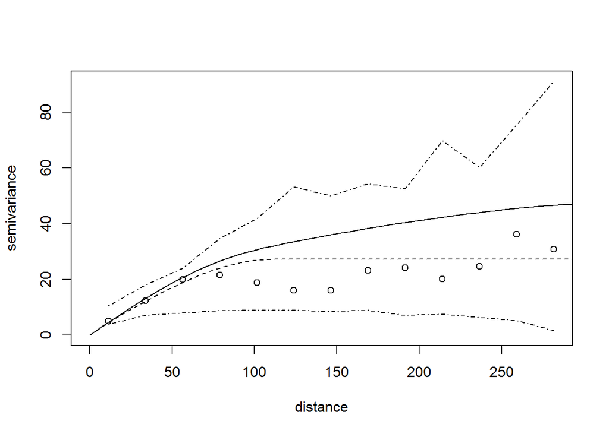

```r
plot(vario, env = vario_env)
lines(kb1, summary.posterior = mean)
lines(kb1, summ = median, lty = 2)
legend(0.15, 150, legend = c("posterior mean",
  "posterior median"), lty = c(1, 2), lwd = c(1, 1), cex = 0.8)
```

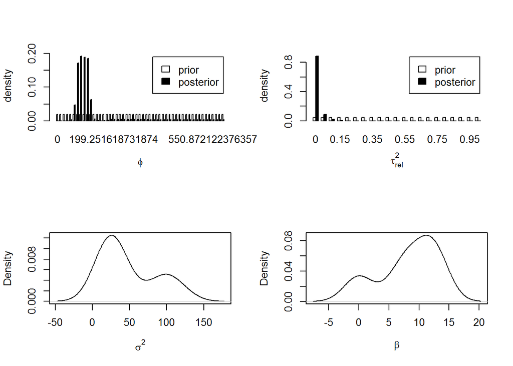

```r
# And the posterior distribution for the four parameters
par(mfrow = c(2, 2))
plot(kb1)
plot(density(kb1$posterior$sample$sigmasq), main = "", xlab = expression(sigma^2))
plot(density(kb1$posterior$sample$beta), main = "", xlab = expression(beta))
```

It is good to consider if there might be mean trends - for example, relationships between the response (i.e. rainfall) and covariates for which we have data (i.e. altitude) so that these can be accommodated in the model. Later, we could consider if it is better to model these relationships or spatial trends. Here we explore these relationships for both the estimation (n=100) and validataion (n=367) datasets.

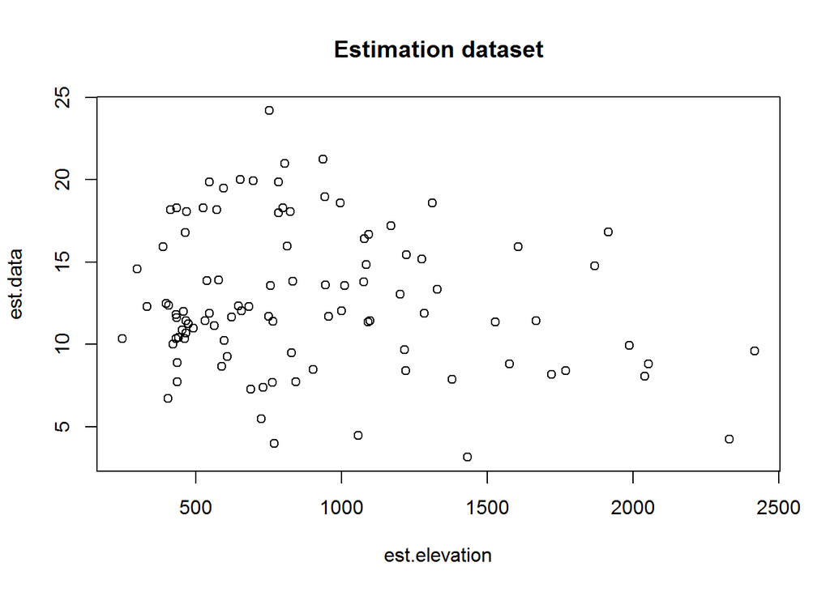

```r
plot(est.data ~ est.elevation, main="Estimation dataset")
```

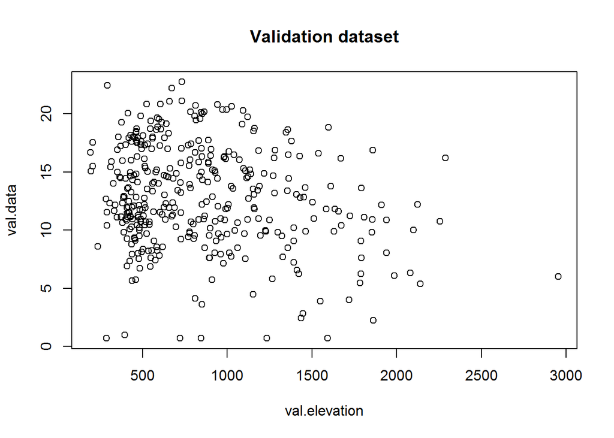

```r
plot(val.data ~ val.elevation, main="Validation dataset")
```

```r
lm1 <- lm(est.data ~ est.elevation)
summary(lm1)
```

```
##
## Call:
## lm(formula = est.data ~ est.elevation)
##
## Residuals:
##     Min      1Q  Median      3Q     Max
## -8.9070 -2.9051 -0.9749  3.4518 11.2529
##
## Coefficients:
##                 Estimate Std. Error t value Pr(>|t|)
## (Intercept)   14.1273080  0.9001064  15.695   <2e-16 ***
## est.elevation -0.0015849  0.0008884  -1.784   0.0775 .
## ---
## Signif. codes:  0 '***' 0.001 '**' 0.01 '*' 0.05 '.' 0.1 ' ' 1
##
## Residual standard error: 4.275 on 98 degrees of freedom
## Multiple R-squared:  0.03145,    Adjusted R-squared:  0.02157
## F-statistic: 3.182 on 1 and 98 DF,  p-value: 0.07754
```

```r
lm2 <- lm(val.data ~ val.elevation)
summary(lm2)
```

```
##
## Call:
## lm(formula = val.data ~ val.elevation)
##
## Residuals:
##      Min       1Q   Median       3Q      Max
## -13.3489  -2.8169   0.0259   3.3654   9.6144
##
## Coefficients:
##                 Estimate Std. Error t value Pr(>|t|)
## (Intercept)   14.6610607  0.4712874  31.109  < 2e-16 ***
## val.elevation -0.0021008  0.0004931  -4.261  2.6e-05 ***
## ---
## Signif. codes:  0 '***' 0.001 '**' 0.01 '*' 0.05 '.' 0.1 ' ' 1
##
## Residual standard error: 4.281 on 365 degrees of freedom
## Multiple R-squared:  0.04738,    Adjusted R-squared:  0.04477
## F-statistic: 18.15 on 1 and 365 DF,  p-value: 2.599e-05
```

The regression model indicates for the larger dataset there is a significant relationship between the two variables, so we will try to model this mean, linear trend ($\beta$ parameters) - notice the new formulation of model.control. In doing this, we remove the trend with altitude and essentially model the spatial patterns in the residuals.

```r
MC2 <- model.control(trend.d=~est.elevation, trend.l=~val.elevation, cov.model="sphe")

maxdist  <- vario.ex$max.dist

PC <- prior.control(beta.prior="flat", sigmasq.prior="reciprocal", phi.prior="uniform",   phi.discrete=seq(0, 2*maxdist, l = 51), tausq.rel.prior="uniform", tausq.rel.discrete = seq(0, 1, by=0.05))

OC <- output.control(n.posterior=10, n.pred = 10, quantile = c(0.1, 0.25, 0.5, 0.75, 0.9))

system.time(
  kb2 <- krige.bayes(data=est.data, coords=est.coord,locations=val.coord,
    borders=sic.borders,model=MC2, prior=PC, output=OC)
)
```

```
## krige.bayes: results will be returned only for prediction locations inside the borders
## krige.bayes: model with mean defined by covariates provided by the user
## krige.bayes: computing the discrete posterior of phi/tausq.rel
## krige.bayes: computing the posterior probabilities.
##              Number of parameter sets:  1071
## 1, 101, 201, 301, 401, 501, 601, 701, 801, 901, 1001,
##
## krige.bayes: sampling from posterior distribution
## krige.bayes: sample from the (joint) posterior of phi and tausq.rel
##               [,1]    [,2]     [,3]     [,4]     [,5]     [,6]
## phi       58.60342 70.3241 93.76547 105.4862 117.2068 410.2239
## tausq.rel  0.00000  0.0000  0.00000   0.0000   0.0000   0.0000
## frequency  1.00000  2.0000  4.00000   1.0000   1.0000   1.0000
##
## krige.bayes: starting prediction at the provided locations
## krige.bayes: phi/tausq.rel samples for the predictive are same as for the posterior
## krige.bayes: computing moments of the predictive distribution
## krige.bayes: sampling from the predictive
##              Number of parameter sets:  6
## 1, 2, 3, 4, 5, 6,
## krige.bayes: preparing summaries of the predictive distribution
```

```
##    user  system elapsed
##   29.36    0.22   30.17
```

Let’s compare the variograms for the two models:

```r
par(mfrow = c(1, 2))
vario <- variog(est.geo)
```

```
## variog: computing omnidirectional variogram
```

```r
plot(vario)
vario2 <- variog(est.geo, trend=~est.elevation)
```

```
## variog: computing omnidirectional variogram
```

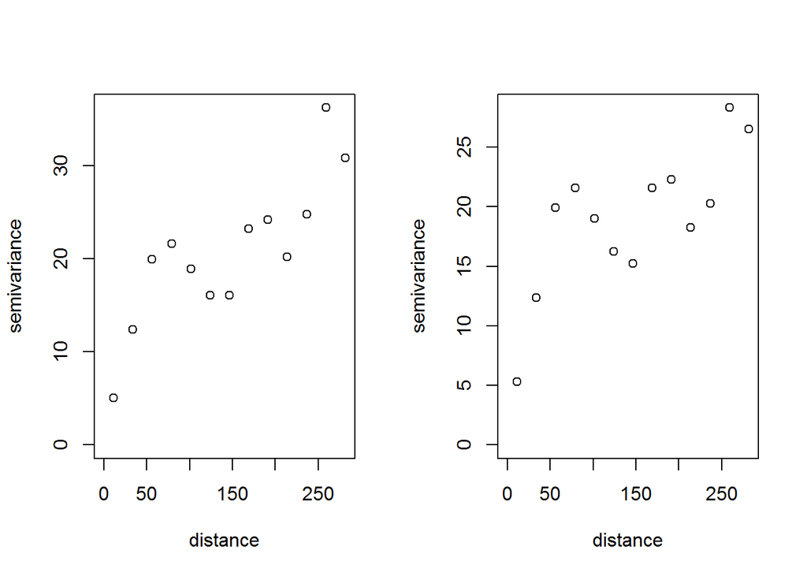

```r
plot(vario2)
```

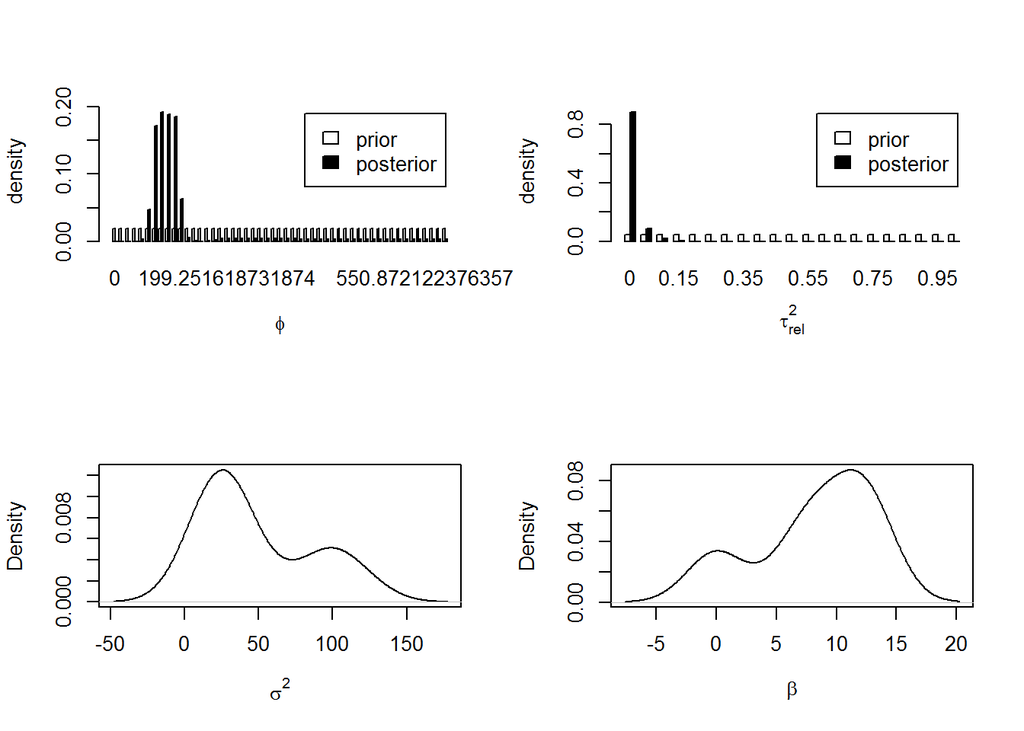

```r
# And the posterior distribution for the four parameters
par(mfrow = c(2, 2))
plot(kb1)
plot(density(kb1$posterior$sample$sigmasq), main = "", xlab = expression(sigma^2))
plot(density(kb1$posterior$sample$beta), main = "", xlab = expression(beta))
```

```r
# Notice the different beta parameters in the two models
colMeans(kb1$posterior$sample)
```

```
##       beta    sigmasq        phi  tausq.rel
##   8.209554  48.188842 173.466115   0.005000
```

```r
colMeans(kb2$posterior$sample)
```

```
##        beta0        beta1      sigmasq          phi    tausq.rel
## 1.111797e+01 5.830284e-04 3.319574e+01 1.207230e+02 0.000000e+00
```

# Model prediction

Lets see how well we have predicted the 367 out-of-sample validation data points with the two models:

```r
names(kb2$predictive)
```

```
## [1] "mean"                  "variance"              "distribution"
## [4] "simulations"           "mean.simulations"      "variance.simulations"
## [7] "quantiles.simulations" "sim.means"
```

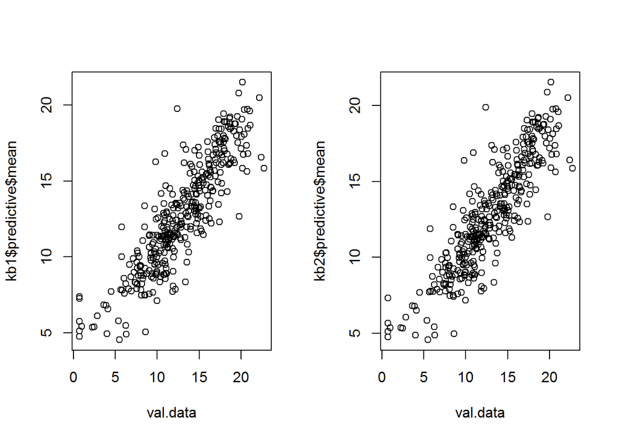

```r
par(mfrow=c(1,2))
plot(kb1$predictive$mean ~ val.data)
plot(kb2$predictive$mean ~ val.data)
```

```r
lm1 <- lm(kb1$predictive$mean ~ val.data)
lm2 <- lm(kb2$predictive$mean ~ val.data)
summary(lm1)
```

```
##
## Call:
## lm(formula = kb1$predictive$mean ~ val.data)
##
## Residuals:
##     Min      1Q  Median      3Q     Max
## -5.1074 -0.9679  0.0265  1.0500  7.3293
##
## Coefficients:
##             Estimate Std. Error t value Pr(>|t|)
## (Intercept)  3.41782    0.28070   12.18   <2e-16 ***
## val.data     0.72566    0.02062   35.20   <2e-16 ***
## ---
## Signif. codes:  0 '***' 0.001 '**' 0.01 '*' 0.05 '.' 0.1 ' ' 1
##
## Residual standard error: 1.728 on 365 degrees of freedom
## Multiple R-squared:  0.7724, Adjusted R-squared:  0.7718
## F-statistic:  1239 on 1 and 365 DF,  p-value: < 2.2e-16
```

```r
summary(lm2)
```

```
##
## Call:
## lm(formula = kb2$predictive$mean ~ val.data)
##
## Residuals:
##     Min      1Q  Median      3Q     Max
## -5.1269 -0.9522  0.0187  1.0684  7.4467
##
## Coefficients:
##             Estimate Std. Error t value Pr(>|t|)
## (Intercept)  3.41527    0.28062   12.17   <2e-16 ***
## val.data     0.72594    0.02061   35.22   <2e-16 ***
## ---
## Signif. codes:  0 '***' 0.001 '**' 0.01 '*' 0.05 '.' 0.1 ' ' 1
##
## Residual standard error: 1.727 on 365 degrees of freedom
## Multiple R-squared:  0.7727, Adjusted R-squared:  0.772
## F-statistic:  1241 on 1 and 365 DF,  p-value: < 2.2e-16
```

What do you notice from these models? How does this relate to what you observed in the variograms?

Now let us predict across the whole of Switzerland. To do this we create a new prediction grid. (Note - why below do we revert to the constant mean model?)

```r
pred.grid <- expand.grid(seq(0,350, l=51),seq (0,220, l=51))
rgb.palette <- colorRampPalette(c("blue", "lightblue",
"orange", "red"),space = "rgb")

MC2 <- model.control(trend.d="cte", trend.l="cte", cov.model="sphe")

maxdist  <- vario.ex$max.dist

PC <- prior.control(beta.prior="flat", sigmasq.prior="reciprocal", phi.prior="uniform",   phi.discrete=seq(0, 2*maxdist, l = 51), tausq.rel.prior="uniform", tausq.rel.discrete = seq(0, 1, by=0.05))

OC <- output.control(n.posterior=10, n.pred = 10, quantile = c(0.1, 0.25, 0.5, 0.75, 0.9))
system.time(
  kb3 <- krige.bayes(data=est.data, coords=est.coord,locations=pred.grid,
    borders=sic.borders,model=MC2, prior=PC, output=OC)
)
```

```
## krige.bayes: results will be returned only for prediction locations inside the borders
## krige.bayes: model with constant mean
## krige.bayes: computing the discrete posterior of phi/tausq.rel
## krige.bayes: computing the posterior probabilities.
##              Number of parameter sets:  1071
## 1, 101, 201, 301, 401, 501, 601, 701, 801, 901, 1001,
##
## krige.bayes: sampling from posterior distribution
## krige.bayes: sample from the (joint) posterior of phi and tausq.rel
##               [,1]     [,2]     [,3]     [,4]     [,5]     [,6]
## phi       58.60342 82.04478 93.76547 105.4862 468.8273 93.76547
## tausq.rel  0.00000  0.00000  0.00000   0.0000   0.0000  0.05000
## frequency  1.00000  1.00000  2.00000   2.0000   1.0000  3.00000
##
## krige.bayes: starting prediction at the provided locations
## krige.bayes: phi/tausq.rel samples for the predictive are same as for the posterior
## krige.bayes: computing moments of the predictive distribution
## krige.bayes: sampling from the predictive
##              Number of parameter sets:  6
## 1, 2, 3, 4, 5, 6,
## krige.bayes: preparing summaries of the predictive distribution
```

```
##    user  system elapsed
##  178.38    8.10  192.70
```

```r
names(kb3)
```

```
## [1] "posterior"    "predictive"   "prior"        "model"
## [5] ".Random.seed" "max.dist"     "call"
```

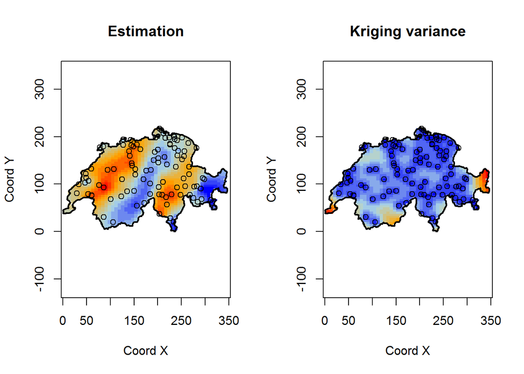

```r
par(mfrow=c(1,2))
image(kb3, values=kb3$predictive$mean, loc = pred.grid,col =rgb.palette(20) ,xlab="Coord X",ylab="Coord Y",borders=sic.borders,main="Estimation")
points(est.coord)

image(kb3, values=kb3$predictive$variance,loc = pred.grid,col=rgb.palette(20),
xlab="Coord X",ylab="Coord Y",borders=sic.borders,
main="Kriging variance")
points(est.coord)
```

What do you notice about the variance (uncertainty) - where is it higher and why?

# Open-ended tasks

- Try fitting different covariance models (e.g. Matern; exponential). What do you notice about the variograms, fitted values and variance when different models are used?
- Try fitting different priors - how much do these choices affect the model results and uncertainty?